# Reproducible Research: Peer Assessment 1

## Loading and preprocessing the data

```r
file <- 'activity.zip'

zipFileInfo <- unzip(file, list=TRUE)

data <- read.csv(unz(file, as.character(zipFileInfo$Name)))

data$date <- as.Date(as.character(data$date) , format = "%Y-%m-%d")

data.sum <- aggregate(x = data[c("steps")],
                     FUN = sum,
                     by = list(date = data$date))


data.average <- aggregate(x = data[c("steps")],
                          FUN = mean,
                          by = list(interval = data$interval),
                          na.rm = TRUE)
```

## What is mean total number of steps taken per day?

Histogram of the total number of steps taken each day:

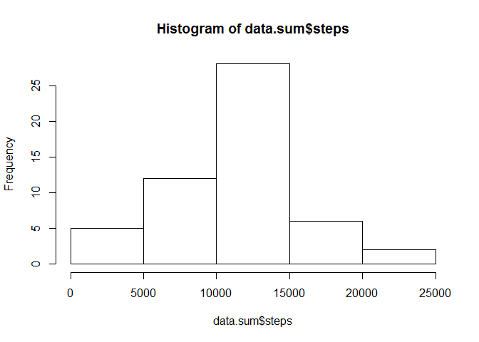

```r
hist(data.sum$steps)
```

Mean total number of steps taken per day:

```r
mean(data.sum$steps, na.rm = TRUE)
```

```
## [1] 10766.19
```

Median total number of steps taken per day:

```r
median(data.sum$steps, na.rm = TRUE)
```

```
## [1] 10765
```

## What is the average daily activity pattern?

Time series plot of the 5-minute interval (x-axis) and the average number of steps taken, averaged across all days (y-axis):

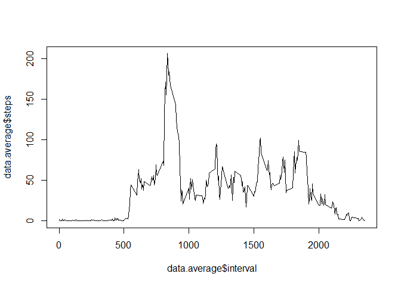

```r
plot(x = data.average$interval, y = data.average$steps,type = "l")
```

5-minute interval Which contains the maximum number of steps on average across all the days in the dataset:

```r
data.average$interval[which.max( data.average$steps )]
```

```
## [1] 835
```

## Imputing missing values

Total number of missing values in the dataset:

```r
sum(is.na(data$steps))
```

```
## [1] 2304
```

New dataset with the missing values filled by the mean of 5-minute interval:

```r
newData <- data

missing <- is.na(newData$steps)

newData$steps[missing] <- as.numeric(data.average$steps)

newData.sum <- aggregate(x = newData[c("steps")],
                      FUN = sum,
                      by = list(date = newData$date))
```

histogram of the total number of steps taken each day:

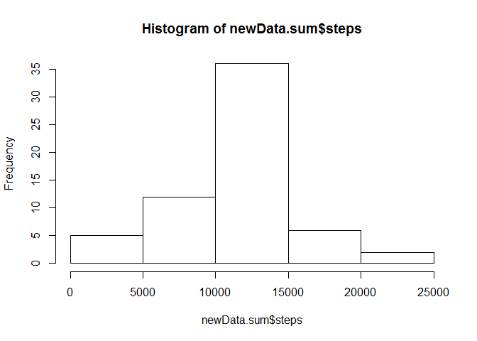

```r
hist(newData.sum$steps)
```

Mean of the total number of steps taken per day:

```r
mean(newData.sum$steps)
```

```
## [1] 10766.19
```

Median of the total number of steps taken per day:

```r
median(newData.sum$steps)
```

```
## [1] 10766.19
```

These values compared to the initial dataset differ only from the last median.

## Are there differences in activity patterns between weekdays and weekends?

New factor variable in the dataset with two levels – “weekday” and “weekend” indicating whether a given date is a weekday or weekend day:

```r
newData$day <- weekdays(newData$date)

newData$day[newData$day == "Saturday" | newData$day ==  "Sunday"] <- "weekend"

newData$day[newData$day != "weekend"] <- "weekday"

newData$day <- as.factor(newData$day)
```

Panel plot containing a time series plot of the 5-minute interval (x-axis) and the average number of steps taken, averaged across all weekday days or weekend days (y-axis):

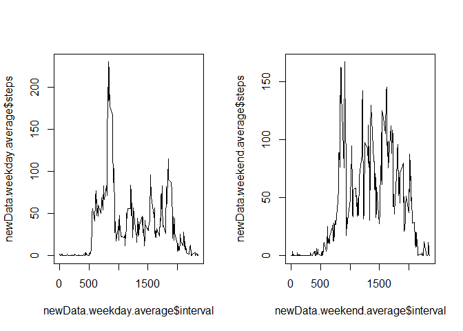

```r
# split data frame
list_week <- split(newData, newData$day)

# aggregate the data frame by average of number steps taken
newData.weekday.average <- aggregate(x = list_week[[1]][c("steps")],
                          FUN = mean,
                          by = list(interval = list_week[[1]]$interval))

newData.weekend.average <- aggregate(x = list_week[[2]][c("steps")],
                                     FUN = mean,
                                     by = list(interval = list_week[[2]]$interval))

# plot the average steps X interval
par(mfrow=c(1,2))

plot(x = newData.weekday.average$interval, y = newData.weekday.average$steps, type = "l")

plot(x = newData.weekend.average$interval, y = newData.weekend.average$steps, type = "l")
```